# Session 1

## Factors

[figure not shown]

Factors are used to represent categorical data. They are kind of ordered labelled vectors. Factors are an important class for statistical analysis and helpful in plotting. The factor() allows us to create factors.

Syntax: factor(x, levels)

```r
#factor()
cities_vec <- c("Vancouver", "Burnaby", "Tehran", "Vancouver", "Tehran")
cities_fac <- factor(x = cities_vec)
cities_fac
```

```
## [1] Vancouver Burnaby   Tehran    Vancouver Tehran
## Levels: Burnaby Tehran Vancouver
```

```r
cities_fac <- factor(x = cities_vec, levels = sort(unique(cities_vec)))
cities_fac
```

```
## [1] Vancouver Burnaby   Tehran    Vancouver Tehran
## Levels: Burnaby Tehran Vancouver
```

```r
# unique() returns a vector/data frame with duplicate elements/rows removed
# we know sort() from the last part. When you sort a vector of characters, it will sort it alphabetically.
```

The factor is a type of data.

```r
class(cities_fac)
```

```
## [1] "factor"
```

You can relevel your factor object or display it by levels(). Syntax: levels(x)

```r
l_vec <- levels(cities_fac)
l_vec
```

```
## [1] "Burnaby"   "Tehran"    "Vancouver"
```

```r
levels(cities_fac) <- rev(l_vec) # rev() reverses a vector
cities_fac
```

```
## [1] Burnaby   Vancouver Tehran    Burnaby   Tehran
## Levels: Vancouver Tehran Burnaby
```

## Data Frames

A data frame is the most common way of sorting data in R. It is a list of equal-length vectors. It is table shaped and has columns and rows.

Column names should not be empty in a data frame. Row names should be unique.

### Creating

You can create a data frame with data.frame()

Syntax: data.frame(vec1, vec2, vec3, …)

```r
# creating a data frame
heroes_df <- data.frame(name = c("ironman", "spiderman", "batman"),
                 strength_score = c(10, 8, 8.2))
print(heroes_df)
```

```
##        name strength_score
## 1   ironman           10.0
## 2 spiderman            8.0
## 3    batman            8.2
```

```r
# you can add row names when you are creating the data frame by adding a row.names argument
heroes_df <- data.frame(name = c("ironman", "spiderman", "batman"),
                 strength_score = c(10, 8, 8.2),
                 row.names = c("hero_1", "hero_2", "hero_3"))
print(heroes_df)
```

```
##             name strength_score
## hero_1   ironman           10.0
## hero_2 spiderman            8.0
## hero_3    batman            8.2
```

```r
# we can add a new column with the $ operator.
heroes_df$assigned_color <- c("red", "red&blue", "black")
heroes_df
```

```
##             name strength_score assigned_color
## hero_1   ironman           10.0            red
## hero_2 spiderman            8.0       red&blue
## hero_3    batman            8.2          black
```

### Subsetting

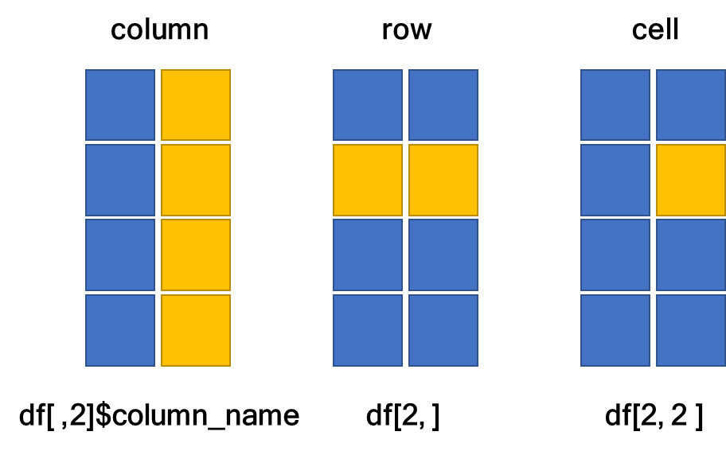

When we don’t specify the row index or column index, we select all of them.

```r
# column
heroes_df[, 1]
```

```
## [1] "ironman"   "spiderman" "batman"
```

```r
heroes_df$strength_score
```

```
## [1] 10.0  8.0  8.2
```

```r
# row
heroes_df[2, ]
```

```
##             name strength_score assigned_color
## hero_2 spiderman              8       red&blue
```

```r
# a cell
heroes_df[1, 2]
```

```
## [1] 10
```